# Introduction

In this project, I decided to use Titanic Data due to two reasons: First, I’m not a fan of baseball. I don’t know much about this game, not even the rules. Second, I am aware of what happened with the Titanic, basically from what I saw in the movie. So it gave me enough curiosity to look at the data, and tried to picture out what data is trying to convey.

In this project i used ipython notebook to analyzed the data, specifically the libraries numpy, pandas and scipy.

```python
import pandas as pd
import matplotlib.pyplot as plt
%matplotlib inline
import numpy as np
import seaborn as sns
```

# Data

Titanic Data - Contains demographics and passenger information from 891 of the 2224 passengers and crew on board the Titanic. You can view a description of this dataset on the Kaggle website where the data was obtained.

```python
titanic_data = pd.read_csv('titanic_data.csv')
```

```python
titanic_data.shape
```

```
(891, 12)
```

```python
titanic_data.head(3)
```

|  | PassengerId | Survived | Pclass | Name | Sex | Age | SibSp | Parch | Ticket | Fare | Cabin | Embarked |
| --- | --- | --- | --- | --- | --- | --- | --- | --- | --- | --- | --- | --- |
| 0 | 1 | 0 | 3 | Braund, Mr. Owen Harris | male | 22.0 | 1 | 0 | A/5 21171 | 7.2500 | NaN | S |
| 1 | 2 | 1 | 1 | Cumings, Mrs. John Bradley (Florence Briggs Th... | female | 38.0 | 1 | 0 | PC 17599 | 71.2833 | C85 | C |
| 2 | 3 | 1 | 3 | Heikkinen, Miss. Laina | female | 26.0 | 0 | 0 | STON/O2. 3101282 | 7.9250 | NaN | S |

# Question of Analysis

The objective of this study is to determine the factors that have affected the survivorship of the passengers in the titanic incident. Specifically, if gender, passenger class which describes the socio-economic status, age, port of embarkation, being with someone or alone during the incident have affected their survival chances.

# Overview of the Summary Statistics of the Dataset

```python
titanic_data.describe()
```

|  | PassengerId | Survived | Pclass | Age | SibSp | Parch | Fare |
| --- | --- | --- | --- | --- | --- | --- | --- |
| count | 891.000000 | 891.000000 | 891.000000 | 714.000000 | 891.000000 | 891.000000 | 891.000000 |
| mean | 446.000000 | 0.383838 | 2.308642 | 29.699118 | 0.523008 | 0.381594 | 32.204208 |
| std | 257.353842 | 0.486592 | 0.836071 | 14.526497 | 1.102743 | 0.806057 | 49.693429 |
| min | 1.000000 | 0.000000 | 1.000000 | 0.420000 | 0.000000 | 0.000000 | 0.000000 |
| 25% | 223.500000 | 0.000000 | 2.000000 | NaN | 0.000000 | 0.000000 | 7.910400 |
| 50% | 446.000000 | 0.000000 | 3.000000 | NaN | 0.000000 | 0.000000 | 14.454200 |
| 75% | 668.500000 | 1.000000 | 3.000000 | NaN | 1.000000 | 0.000000 | 31.000000 |
| max | 891.000000 | 1.000000 | 3.000000 | 80.000000 | 8.000000 | 6.000000 | 512.329200 |

From the basic describe function of panda, we already have an overview of the data.

Around 38.38% survived the incident,

Average age of the passenger is 29 yrs old, oldest we have is 80 y.o., and the youngest is a newborn child of about 5 months old

Average fare is 32 USD, highest fare is 512.33 USD. Median is 14.45 USD, lower than the mean.

# Defining Functions for Dataframe Transformations

Let's categorize the passengers into child or not. Let's consider any passenger below 16 yrs of age to be a child.

```python
def male_female_child(passenger):
    age,sex = passenger
    if age<16:
        return 'child'
    else:
        return sex
```

```python
titanic_data['People'] = titanic_data[['Age','Sex']].apply(male_female_child, axis=1)
```

Let's now categorize if a passenger was with someone or alone during the incident.

```python
def is_withsomeone(titanic):
    if titanic['SibSp'] > 0 or titanic['Parch'] > 0:
        return 1
    else:
        return 0
```

```python
titanic_data['is_withsomeone'] = titanic_data.apply(is_withsomeone, axis=1)
```

To further simplify analysis involving age, let's categorize whether a passenger was a child or adult.

```python
def is_child(titanic):
    if titanic['Age'] < 16:
        return 'child'
    else:
        return 'adult'
```

```python
titanic_data['child_or_adult'] = titanic_data.apply(is_child, axis=1)
```

```python
titanic_data.head()
```

|  | PassengerId | Survived | Pclass | Name | Sex | Age | SibSp | Parch | Ticket | Fare | Cabin | Embarked | People | is_withsomeone | child_or_adult |
| --- | --- | --- | --- | --- | --- | --- | --- | --- | --- | --- | --- | --- | --- | --- | --- |
| 0 | 1 | 0 | 3 | Braund, Mr. Owen Harris | male | 22.0 | 1 | 0 | A/5 21171 | 7.2500 | NaN | S | male | 1 | adult |
| 1 | 2 | 1 | 1 | Cumings, Mrs. John Bradley (Florence Briggs Th... | female | 38.0 | 1 | 0 | PC 17599 | 71.2833 | C85 | C | female | 1 | adult |
| 2 | 3 | 1 | 3 | Heikkinen, Miss. Laina | female | 26.0 | 0 | 0 | STON/O2. 3101282 | 7.9250 | NaN | S | female | 0 | adult |
| 3 | 4 | 1 | 1 | Futrelle, Mrs. Jacques Heath (Lily May Peel) | female | 35.0 | 1 | 0 | 113803 | 53.1000 | C123 | S | female | 1 | adult |
| 4 | 5 | 0 | 3 | Allen, Mr. William Henry | male | 35.0 | 0 | 0 | 373450 | 8.0500 | NaN | S | male | 0 | adult |

# Survivorship Factors

Let's see first the Gender, Pclass, and Fare factors.

```python
titanic_data[(titanic_data.Sex.isnull()) | (titanic_data.Pclass.isnull()) | (titanic_data.Fare.isnull())]
```

|  | PassengerId | Survived | Pclass | Name | Sex | Age | SibSp | Parch | Ticket | Fare | Cabin | Embarked | People | is_withsomeone | child_or_adult |
| --- | --- | --- | --- | --- | --- | --- | --- | --- | --- | --- | --- | --- | --- | --- | --- |

It was good to see that there's no missing values for Sex, Fare and Pclass columns. I was able to easily use these factors to analyze if these had impact on the survival of the passengers.

```python
pd.crosstab(titanic_data["Survived"], titanic_data["Sex"], margins = True)
```

| Sex Survived | female | male | All |
| --- | --- | --- | --- |
| 0 | 81 | 468 | 549 |
| 1 | 233 | 109 | 342 |
| All | 314 | 577 | 891 |

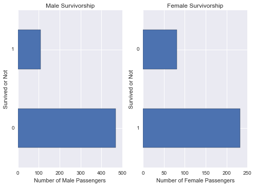

```python
fig, axs = plt.subplots(1,2)
ax = titanic_data[titanic_data.Sex == "male"].Survived.value_counts().plot(kind = "barh", ax = axs[0], title = "Male Survivorship")
ax.set(xlabel="Number of Male Passengers", ylabel="Survived or Not")
ax = titanic_data[titanic_data.Sex == "female"].Survived.value_counts().plot(kind = "barh", ax = axs[1], title = "Female Survivorship")
ax.set(xlabel="Number of Female Passengers", ylabel="Survived or Not")
```

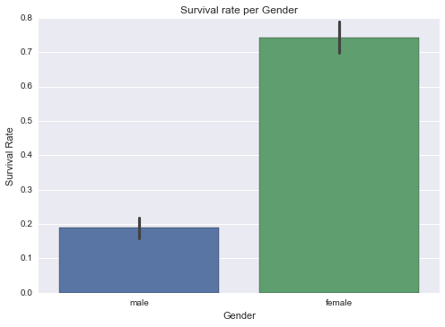

```python
ax = sns.barplot(x="Sex", y="Survived", data=titanic_data)
ax.set(xlabel="Gender", ylabel="Survival Rate", title = 'Survival rate per Gender')
```

Here, we can see that female had higher percentage of survival in the incident than male.

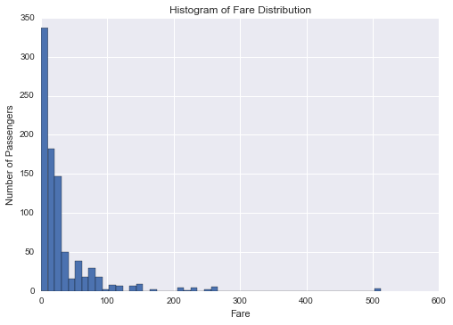

```python
ax = titanic_data.Fare.plot(kind='hist', bins = 50)
ax.set(xlabel="Fare", ylabel="Number of Passengers", title = 'Histogram of Fare Distribution')
```

We can see very few passengers that paid a lot for this trip.

```python
titanic_data.Fare.describe()
```

```
count    891.000000
mean      32.204208
std       49.693429
min        0.000000
25%        7.910400
50%       14.454200
75%       31.000000
max      512.329200
Name: Fare, dtype: float64
```

Majority of the passengers paid less than 30 bucks.

```python
titanic_data[titanic_data.Fare>500]
```

|  | PassengerId | Survived | Pclass | Name | Sex | Age | SibSp | Parch | Ticket | Fare | Cabin | Embarked | People | is_withsomeone | child_or_adult |
| --- | --- | --- | --- | --- | --- | --- | --- | --- | --- | --- | --- | --- | --- | --- | --- |
| 258 | 259 | 1 | 1 | Ward, Miss. Anna | female | 35.0 | 0 | 0 | PC 17755 | 512.3292 | NaN | C | female | 0 | adult |
| 679 | 680 | 1 | 1 | Cardeza, Mr. Thomas Drake Martinez | male | 36.0 | 0 | 1 | PC 17755 | 512.3292 | B51 B53 B55 | C | male | 1 | adult |
| 737 | 738 | 1 | 1 | Lesurer, Mr. Gustave J | male | 35.0 | 0 | 0 | PC 17755 | 512.3292 | B101 | C | male | 0 | adult |

These three had same ticket number, same fare amount, and embarked at the same location. Out of curiousity, i searched them in google. From encyclopedia-titanica.org,

"Mr Thomas Drake Martinez Cardeza, 36, from Germantown, PA, boarded the Titanic at Cherbourg with his mother Charlotte Cardeza and his manservant Gustave Lesueur.", and

Anna Ward worked as personal maid and companion to Mrs Charlotte Cardeza.

Since Fare is somehow reflected in Pclass, I just cheked Pclass as a factor of survivorship.

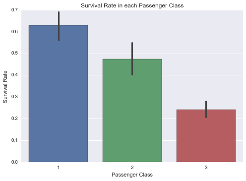

```python
ax = sns.barplot(x="Pclass", y="Survived", data=titanic_data)
ax.set(xlabel="Passenger Class", ylabel="Survival Rate", title = 'Survival Rate in each Passenger Class')
```

We can also see here that those people in the upper passenger class (Pclass =1) had higher survival rate than the others.

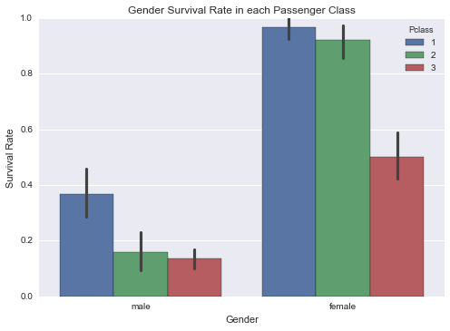

```python
ax = sns.barplot(x="Sex", y ="Survived", hue="Pclass", data = titanic_data)
ax.set(xlabel="Gender", ylabel="Survival Rate", title = 'Gender Survival Rate in each Passenger Class')
```

So, it seems gender and passenger class have affected the survival chances of the passengers.

Let's now check the Age.

```python
titanic_data[titanic_data.Age.isnull()].shape
```

```
(177, 15)
```

```python
print ("{0:.0f}%".format(177/891.0 * 100))
```

```
20%
```

Unfortunately, we have missing values for the Age column, and it is about 20% of our dataset.

The next question is how are we going to deal with it? I had two options in mind.

Create a new dataset where all entries for Age column are not null and use this in every analysis involving age;

Fill all those missing values for age with the value of average age.

In this case, i chose to apply the first option.

I defined a separate dataset where the is no null entries for age, and used it whenever age is involve.

```python
titanic_data2 = titanic_data[~titanic_data.Age.isnull()]
```

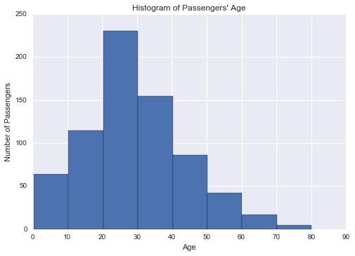

```python
titanic_data2.Age.hist(bins=8)
plt.xlabel("Age")
plt.ylabel("Number of Passengers")
plt.title("Histogram of Passengers' Age");
```

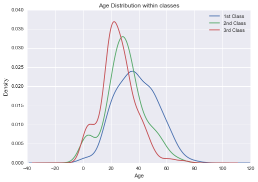

```python
titanic_data2.Age[titanic_data2.Pclass == 1].plot(kind='kde')
titanic_data2.Age[titanic_data2.Pclass == 2].plot(kind='kde')
titanic_data2.Age[titanic_data2.Pclass == 3].plot(kind='kde')
plt.xlabel("Age")
plt.title("Age Distribution within classes")
plt.legend(('1st Class', '2nd Class','3rd Class'),loc='best')
```

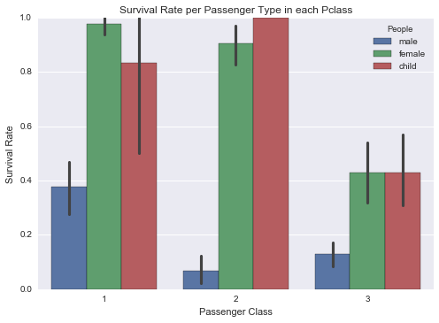

```python
ax = sns.barplot(x="Pclass", y ="Survived", hue="People", data = titanic_data2)
ax.set(xlabel="Passenger Class", ylabel="Survival Rate", title = 'Survival Rate per Passenger Type in each Pclass')
```

From the graph above, we can see that females and children had higher survival rate in the incident than males.

Let's now see the columns Cabin, Fare, and Embark columns.

```python
titanic_data[titanic_data.Cabin.isnull()].shape
```

```
(687, 15)
```

Due to very high missing values of the Cabin column, i decided not to look deeper in to this.

```python
titanic_data[titanic_data.Embarked.isnull()].shape
```

```
(2, 15)
```

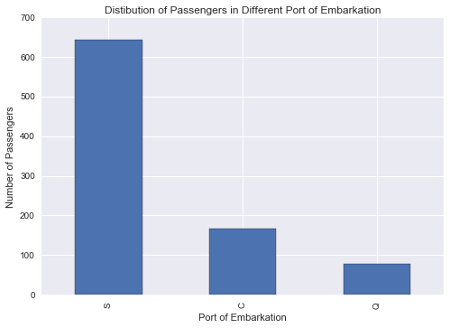

```python
ax = titanic_data.Embarked.value_counts().plot(kind = 'bar')
ax.set(xlabel="Port of Embarkation", ylabel="Number of Passengers", title = 'Distibution of Passengers in Different Port of Embarkation')
```

Majority of the passengers embarked at Port Southhampton.

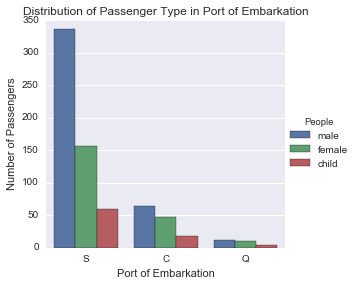

```python
ax = sns.factorplot('Embarked',data=titanic_data2,hue='People',kind='count')
ax.set(xlabel="Port of Embarkation", ylabel="Number of Passengers", title = 'Distribution of Passenger Type in Port of Embarkation')
```

We can see here the volume of male, female, and child in each port of embarkation.

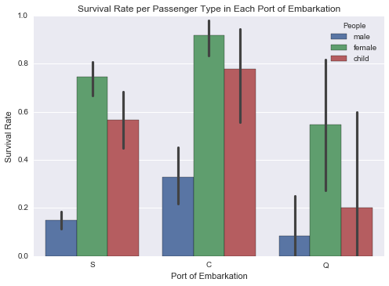

```python
ax = sns.barplot(x="Embarked", y ="Survived", hue="People", data = titanic_data2)
ax.set(xlabel="Port of Embarkation", ylabel="Survival Rate", title = 'Survival Rate per Passenger Type in Each Port of Embarkation')
```

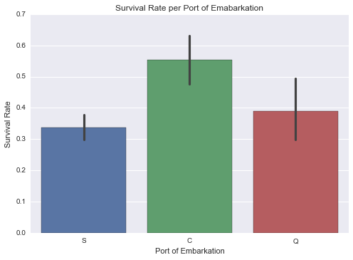

```python
ax = sns.barplot(x="Embarked", y ="Survived", data = titanic_data)
ax.set(xlabel="Port of Embarkation", ylabel="Survival Rate", title = 'Survival Rate per Port of Emabarkation')
```

We can see here clearly that those who embarked at Cherbourg had higher chance of survival than the rest.

```python
titanic_data[(titanic_data.SibSp.isnull()) | titanic_data.Parch.isnull()].shape
```

```
(0, 15)
```

Now, lets see if being alone, or having someone to protect to or to protect you had impact in the survivorship.

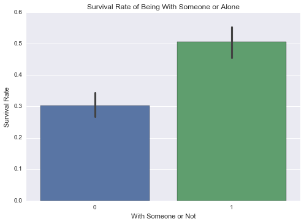

```python
ax = sns.barplot(x="is_withsomeone", y ="Survived", data = titanic_data)
ax.set(xlabel="With Someone or Not", ylabel="Survival Rate", title = 'Survival Rate of Being With Someone or Alone')
```

We can clearly see here that being with someone at that time possibly gave them enough motivation to survive.

# Test of Independence

This part tested the independence of each identified factors, Sex, Pclass, Age - Child or Not, Being alone or with someone, and the Embarked factor to the survivorship of the passengers.

**Testing Sex Factor**

Ho: Gender does not significantly affect the survivorship of a passenger in the titanic incident.

Ha: Gender significantly affects the survivorship of a passenger in the titanic incident.

Since our dependent variable is categorical, I applied chi-square independence test.

```python
from scipy.stats import chi2_contingency
```

```python
pivot_sex_survived = pd.pivot_table(data = titanic_data[['Survived', 'Sex']], index = 'Survived', columns = ['Sex'], aggfunc = len)
```

```python
pivot_sex_survived
```

| Sex Survived | female | male |
| --- | --- | --- |
| 0 | 81 | 468 |
| 1 | 233 | 109 |

```python
def chi_square_test(ind_var, dep_var, dataset):
    pivot = pd.pivot_table(data = dataset[[dep_var, ind_var]], index = dep_var, columns = [ind_var], aggfunc = len)
    print(pivot)
    print ("\n")
    chi2, p_value, dof, expected = chi2_contingency(pivot)
    print ("Results of Chi-Squared test on {} to {}.".format(ind_var,dep_var))
    print ("Chi-Squared Score = " + str(chi2))
    print ("Pvalue = " + str(p_value))
```

```python
chi_square_test('Sex', 'Survived', titanic_data)
```

```
Sex       female  male
Survived
0             81   468
1            233   109


Results of Chi-Squared test on Sex to Survived.
Chi-Squared Score = 260.717020167
Pvalue = 1.19735706278e-58
```

Since Pvalue = 1.19735706278e-58 < Chi-Squared Score = 260.717020167, then for all reasonable alphas, we have to reject the null hypothesis. Thus, gender indeed was a factor in survivorship in the titanic incident.

**Testing Pclass Factor**

Ho: Pclass does not significantly affect the survivorship of a passenger in the titanic incident.

Ha: Pclass significantly affects the survivorship of a passenger in the titanic incident.

Since our dependent variable is categorical, I applied chi-square independence test.

```python
chi_square_test('Pclass', 'Survived', titanic_data)
```

```
Pclass      1   2    3
Survived
0          80  97  372
1         136  87  119


Results of Chi-Squared test on Pclass to Survived.
Chi-Squared Score = 102.888988757
Pvalue = 4.5492517113e-23
```

Since Pvalue = 4.5492517113e-23 < Chi-Squared Score = 102.888988757, then for all reasonable alphas, we have to reject the null hypothesis. Thus, pclass indeed was a factor in survivorship in the titanic incident.

**Testing Age Factor**

Ho: Being a child or being an adult does not significantly affect the survivorship of a passenger in the titanic incident.

Ha: Being a child or being an adult significantly affects the survivorship of a passenger in the titanic incident.

Since our dependent variable is categorical, I applied chi-square independence test.

```python
chi_square_test('child_or_adult', 'Survived', titanic_data2)
```

```
child_or_adult  adult  child
Survived
0                 390     34
1                 241     49


Results of Chi-Squared test on child_or_adult to Survived.
Chi-Squared Score = 12.3615373505
Pvalue = 0.000438269652287
```

Since Pvalue = 0.000438269652287 < Chi-Squared Score = 12.3615373505, then for all reasonable alphas, we have to reject the null hypothesis. Thus, being a child or adult indeed was a factor in survivorship in the titanic incident.

**Testing Being Alone or With Someone Factor**

Ho: Being alone or being with someone does not significantly affect the survivorship of a passenger in the titanic incident.

Ha: Being alone or being with someone significantly affects the survivorship of a passenger in the titanic incident.

Since our dependent variable is categorical, I applied chi-square independence test.

```python
chi_square_test('is_withsomeone', 'Survived', titanic_data)
```

```
is_withsomeone    0    1
Survived
0               374  175
1               163  179


Results of Chi-Squared test on is_withsomeone to Survived.
Chi-Squared Score = 36.0005144677
Pvalue = 1.97265438465e-09
```

Since Pvalue = 1.97265438465e-09 < Chi-Squared Score = 36.0005144677, then for all reasonable alphas, we have to reject the null hypothesis. Thus, being with someone or being alone indeed was a factor in survivorship in the titanic incident.

**Testing Embarked Factor**

Ho: Port of embarkation does not significantly affect the survivorship of a passenger in the titanic incident.

Ha: Port of embarkation significantly affects the survivorship of a passenger in the titanic incident.

Since our dependent variable is categorical, I applied chi-square independence test.

```python
chi_square_test('Embarked', 'Survived', titanic_data)
```

```
Embarked   C   Q    S
Survived
0         75  47  427
1         93  30  217


Results of Chi-Squared test on Embarked to Survived.
Chi-Squared Score = 26.4891498392
Pvalue = 1.76992228412e-06
```

Since Pvalue = 1.76992228412e-06 < Chi-Squared Score = 26.4891498392, then for all reasonable alphas, we have to reject the null hypothesis. Thus, port of embarkation indeed was a factor in survivorship in the titanic incident.

# Summary

From what we have seen in our charts and visual, and upon verification thru hypothesis testing, we can now say that the factors that affect the survivorship of the passengers in the titanic incident were:

Gender - female had higher survivorship than male;

Pclass - those who were in a higher socio-economic status had higher survivorship than those in the lower socio-economic status;

Age - Children had higher survivorship than adult;

Embarked - those who embarked at Cherbourg had higher survivorship than the others; and

those who were with someone had higher survivorship than those who were alone in the titanic incident.

# Limitations

Since the dataset had a lot of missing values, the remedy applied, which is simply dropping of null values, might not be the best of option for this study. We can test for different ways to handle this limitation such as filling up the missing with the average age value, or apply machine learning algorithm.

Please also note that what we have found in this study are purely correlations of the different factors, and correlation does not imply causation.